# PCA_CLR_based_data

Cassandra Sperow

2023-10-09

## Read in Transformed Data for Principal Components Analysis

- Centered log ratio = CLR
- CLR data transformation recommended by client

```r
read_csv("../output/clr_bac_df.csv") -> clr_bac_df
head(clr_bac_df) # not scaled, only clr transformation
```

```
## # A tibble: 6 × 5,889
##   ASV0001 ASV0002 ASV0003 ASV0004 ASV0005 ASV0006 ASV0007 ASV0008 ASV0009
##     <dbl>   <dbl>   <dbl>   <dbl>   <dbl>   <dbl>   <dbl>   <dbl>   <dbl>
## 1    5.26       0   0        1.18    4.49    4.15    3.97       0    3.80
## 2    3.77       0   0        2.84    5.09    4.69    2.65       0    2.56
## 3    2.81       0  -0.331    1.61    4.94    4.50    1.75       0    1.60
## 4    5.53       0   0        1.75    4.96    4.47    4.38       0    4.25
## 5    5.12       0   0        3.03    5.76    5.05    3.89       0    3.77
## 6    6.39       0   0        2.29    3.78    3.18    5.13       0    4.99
## # ℹ 5,880 more variables: ASV0010 <dbl>, ASV0011 <dbl>, ASV0012 <dbl>,
## #   ASV0013 <dbl>, ASV0014 <dbl>, ASV0015 <dbl>, ASV0016 <dbl>, ASV0017 <dbl>,
## #   ASV0018 <dbl>, ASV0019 <dbl>, ASV0020 <dbl>, ASV0022 <dbl>, ASV0023 <dbl>,
## #   ASV0024 <dbl>, ASV0025 <dbl>, ASV0027 <dbl>, ASV0030 <dbl>, ASV0031 <dbl>,
## #   ASV0032 <dbl>, ASV0033 <dbl>, ASV0034 <dbl>, ASV0035 <dbl>, ASV0036 <dbl>,
## #   ASV0037 <dbl>, ASV0039 <dbl>, ASV0040 <dbl>, ASV0041 <dbl>, ASV0042 <dbl>,
## #   ASV0043 <dbl>, ASV0044 <dbl>, ASV0046 <dbl>, ASV0047 <dbl>, …
```

## Run PCA - Both Species

- Scale = TRUE

```r
stats::prcomp(clr_bac_df, scale. = T) -> pca_out_clr
```

### Screeplot with base::plot()

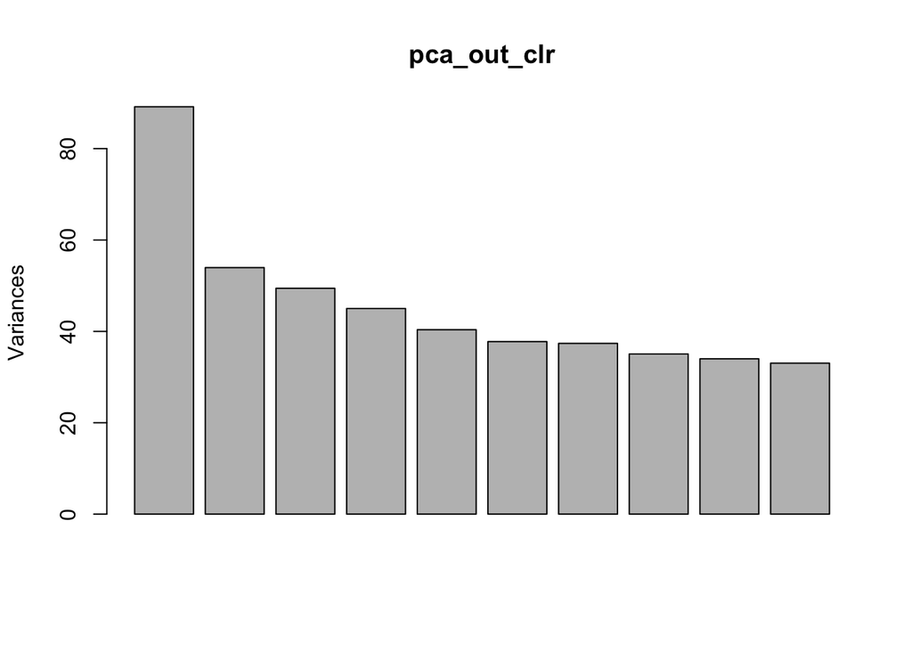

```r
screeplot(pca_out_clr)
```

### Factoextra PCA CLR Visualization - Both Species

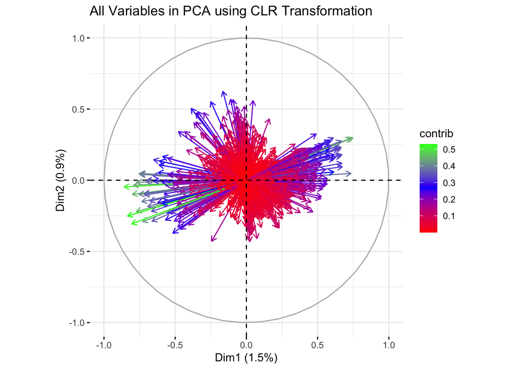

```r
library(factoextra)
fviz_pca_var(pca_out_clr,
             #col.var = "steelblue",
             col.var = "contrib",
             gradient.cols = c("red", "blue", "green"),
            # repel = T,
            label = "none",
             title = "All Variables in PCA using CLR Transformation")
```

```r
summary(pca_out_clr)$importance %>% as_tibble() -> importance_matrix
```

##### Bind Columns of Names of PCA Outputs to View Percentages

```r
bind_cols(
  name = c("StndDev", "IndivProp", "CumProp"),
  importance_matrix
) -> importance_df
```

#### Screeplot vis Ggplot

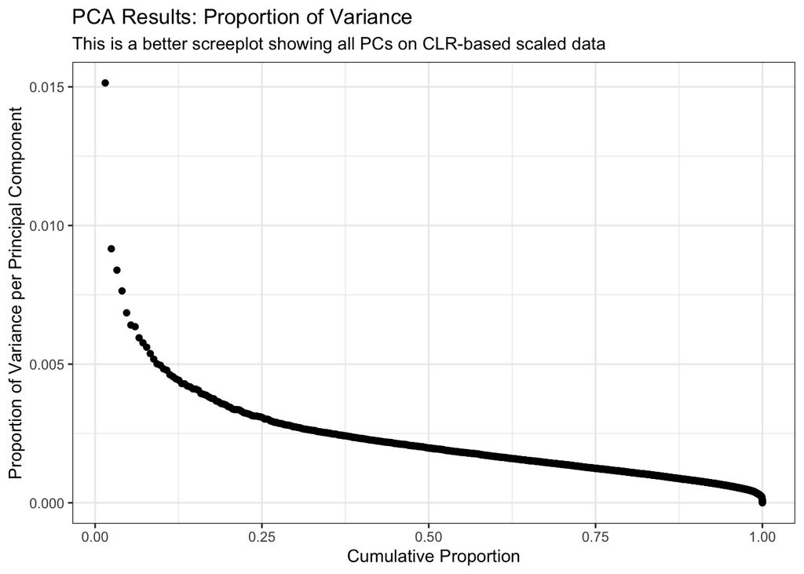

```r
importance_df %>%
  t() %>%
  as.data.frame() %>%
  janitor::row_to_names(1) %>%
  ggplot(aes(x = as.numeric(CumProp) , y =  as.numeric(IndivProp))) +
  geom_point() +
  ggtitle("PCA Results: Proportion of Variance", "This is a better screeplot showing all PCs on CLR-based scaled data") +
  xlab("Cumulative Proportion") +
  ylab("Proportion of Variance per Principal Component") +
  theme_bw()
```

```r
importance_df %>%
  # pivoting data drame so that cumulatives are in column
  t() %>%  as.data.frame() %>%
  # moving up top row as column header
  janitor::row_to_names(1) %>% ######## snapshot here for presentation
  # filtering cumulative proportion column for greater > = 80 %
  filter(CumProp >= 0.8 & CumProp <= 0.78)
```

```
## [1] StndDev   IndivProp CumProp
## <0 rows> (or 0-length row.names)
```

# Split by Species for PCA

## Species P - Import Data

```r
# add back in the sample IDs to separate by species
# read in original data frame from creating the CLR transformation
read_csv("../output/rev_bacteria.csv") -> rev_bacteria
# section out the sample ID column and save
rev_bacteria[,1] -> sample_id_column

# re-combine with clr-transformed data and save
bind_cols(
  sample_id_column,
  clr_bac_df
) -> clr_bac_df_samples
```

#### Split for Species P

```r
clr_bac_df_samples %>%
  # the sample IDs that have a capital S at the beginning of the string are species S
  filter(str_detect(sample_id, "^P")) -> species_P_CLR_DF
```

- PCA can’t rescale a constant 0 column
- Check the columns that sum to 0: 1,110 columns sum to 0 and would not allow PCA to work for species P

```r
# PCA can't rescale a constant 0 column
# Check transformed data for columns that are all 0 values
species_P_CLR_DF[,-1] %>%
  map(., ~sum(.)) %>%
  as.data.frame() %>%
  pivot_longer(cols = everything()) %>%
  filter(value == 0) -> zero_columns
```

- Remove columns identified above for successful run of PCA

```r
species_P_CLR_DF %>%
  select(-(zero_columns$name)) -> pca_data_species_P
```

### Species P - PCA

```r
stats::prcomp(pca_data_species_P[,-1], scale. = T) -> pca_out_P
```

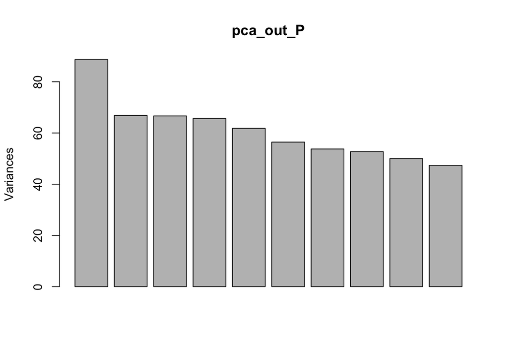

```r
base::plot(pca_out_P)
```

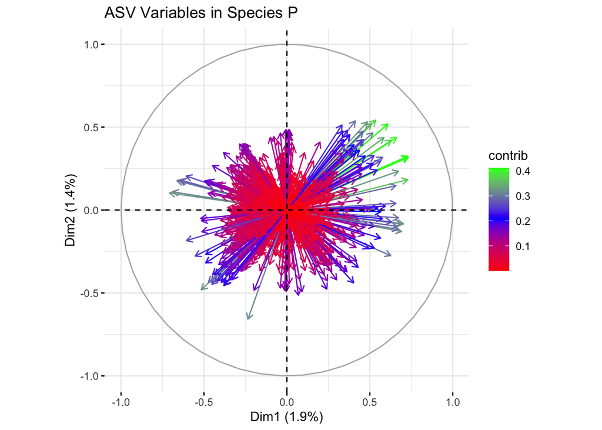

```r
library(factoextra)
fviz_pca_var(pca_out_P,
             #col.var = "steelblue",
             col.var = "contrib",
             gradient.cols = c("red", "blue", "green"),
             #repel = T,
            label = "none",
             title = "ASV Variables in Species P")
```

#### Which of these explain at least 80 % of the variability in species P?

```r
summary(pca_out_P)$importance %>% as_tibble() -> importance_matrix_P
```

```r
bind_cols(
  name = c("StndDev", "IndivProp", "CumProp"),
  importance_matrix_P
) -> species_p_importance
```

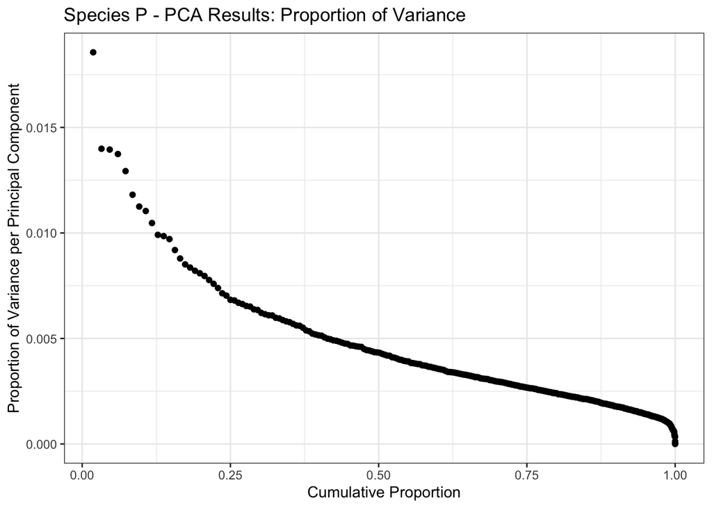

```r
species_p_importance %>%
  t() %>%
  as.data.frame() %>%
  janitor::row_to_names(1) %>%
  ggplot(aes(x = as.numeric(CumProp) , y =  as.numeric(IndivProp))) +
  geom_point() +
  ggtitle("Species P - PCA Results: Proportion of Variance") +
  xlab("Cumulative Proportion") +
  ylab("Proportion of Variance per Principal Component") +
  theme_bw()
```

##### How many PCs contribute to at least 80 % ? 166

```r
species_p_importance %>%
  # pivoting data drame so that cumulatives are in column
  t() %>%  as.data.frame() %>%
  # moving up top row as column header
  janitor::row_to_names(1) %>% ######## snapshot here for presentation
  # filtering cumulative proportion column for greater > = 80 %
  filter(CumProp >= 0.8)
```

```
##            StndDev    IndivProp      CumProp
## PC166     3.388958     0.002400     0.800360
## PC167     3.360257     0.002360     0.802720
## PC168     3.356726     0.002360     0.805080
## PC169     3.353367     0.002350     0.807430
## PC170     3.341578     0.002340     0.809770
## PC171     3.334341     0.002330     0.812100
## PC172     3.325117     0.002310     0.814410
## PC173     3.316891     0.002300     0.816710
## PC174     3.300475     0.002280     0.818990
## PC175      3.29621      0.00227      0.82126
## PC176     3.286755     0.002260     0.823520
## PC177     3.270849     0.002240     0.825760
## PC178     3.270209     0.002240     0.828000
## PC179     3.262072     0.002230     0.830230
## PC180     3.249932     0.002210     0.832440
## PC181     3.247781     0.002210     0.834640
## PC182     3.234038     0.002190     0.836830
## PC183     3.221681     0.002170     0.839010
## PC184      3.21367      0.00216      0.84117
## PC185     3.203969     0.002150     0.843310
## PC186     3.194157     0.002130     0.845450
## PC187     3.192648     0.002130     0.847580
## PC188     3.187313     0.002130     0.849710
## PC189     3.180293     0.002120     0.851820
## PC190     3.169541     0.002100     0.853930
## PC191     3.163486     0.002090     0.856020
## PC192     3.145346     0.002070     0.858090
## PC193     3.141766     0.002070     0.860160
## PC194     3.128435     0.002050     0.862200
## PC195     3.118054     0.002030     0.864240
## PC196     3.103601     0.002020     0.866250
## PC197     3.096552     0.002010     0.868260
## PC198     3.091762     0.002000     0.870260
## PC199     3.079704     0.001980     0.872240
## PC200     3.051391     0.001950     0.874190
## PC201     3.048683     0.001940     0.876140
## PC202     3.029133     0.001920     0.878060
## PC203     3.023946     0.001910     0.879970
## PC204     3.021412     0.001910     0.881880
```

[output cut: 77 more lines]

```
## PC282     1.990793     0.000830     0.993620
## PC283     1.911917     0.000760     0.994390
## PC284     1.865293     0.000730     0.995120
## PC285     1.825167     0.000700     0.995810
## PC286     1.768622     0.000650     0.996470
## PC287     1.744473     0.000640     0.997100
## PC288     1.709923     0.000610     0.997720
## PC289     1.659058     0.000580     0.998290
## PC290     1.478102     0.000460     0.998750
## PC291     1.339847     0.000380     0.999130
## PC292     1.312154     0.000360     0.999490
## PC293     1.275574     0.000340     0.999830
## PC294    0.7960022    0.0001300    0.9999600
## PC295    0.4442002    0.0000400    1.0000000
## PC296 1.027821e-13 0.000000e+00 1.000000e+00
```

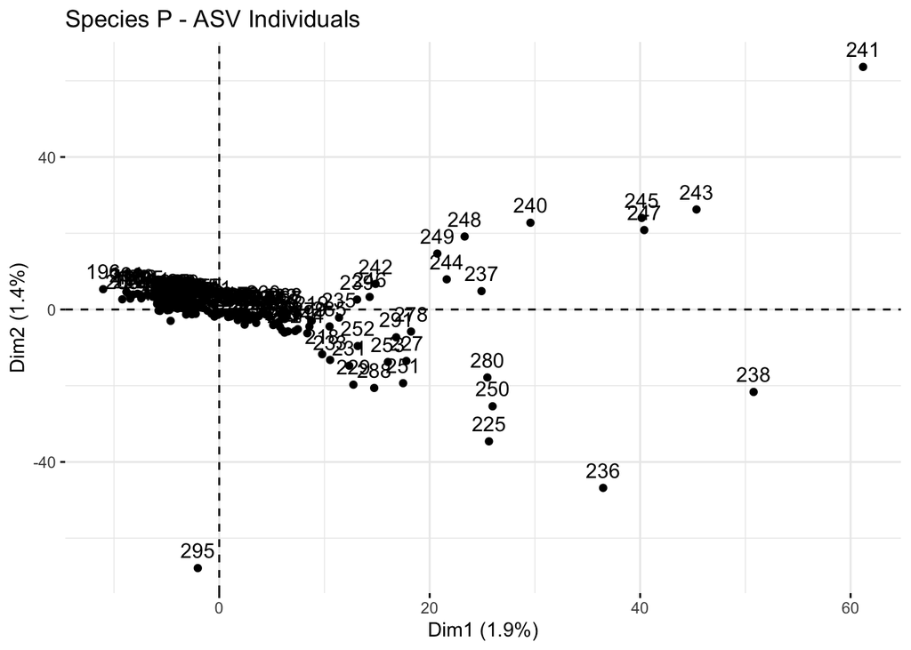

```r
fviz_pca_ind(pca_out_P,
             geom.var = c("point", "text"),
            # repel = T,
             title = "Species P - ASV Individuals")
```

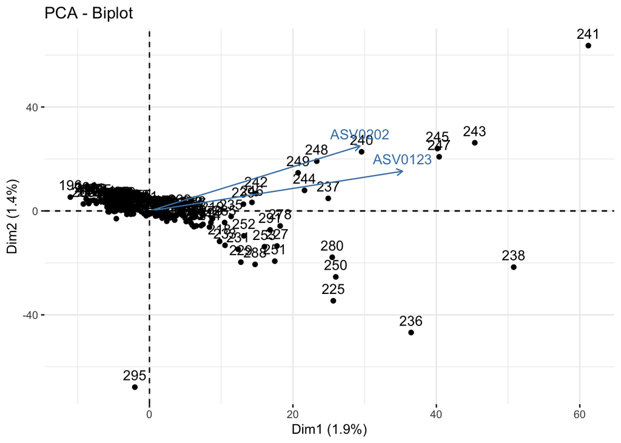

```r
fviz_pca(pca_out_P,
        # col.var = "contrib",
         #select.ind = list(contrib = 10)
         select.var = list(contrib = 2),
         #repel = T
        #label = "none"
         )
```

### Get PCA Variable Names

```r
get_pca_var(pca_out_P)
```

```
## Principal Component Analysis Results for variables
##  ===================================================
##   Name       Description
## 1 "$coord"   "Coordinates for the variables"
## 2 "$cor"     "Correlations between variables and dimensions"
## 3 "$cos2"    "Cos2 for the variables"
## 4 "$contrib" "contributions of the variables"
```

```r
get_pca_var(pca_out_P)$contrib %>%
  as.data.frame() %>%
  arrange(-Dim.1) -> species_P_pca
```

```r
write_csv(species_P_pca, "../output/species_P_pca_ranks.csv")
```

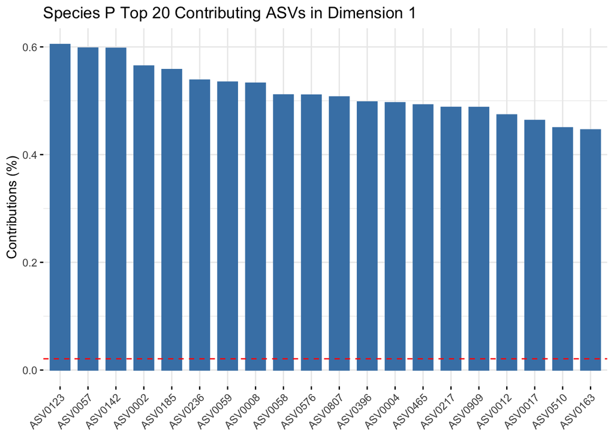

```r
fviz_contrib(pca_out_P, choice = "var", axes = 1, top = 20,
             title = "Species P Top 20 Contributing ASVs in Dimension 1",
             ggtheme = theme_minimal()) -> top_20_pca_P

top_20_pca_P
```

```r
ggsave("../plots/top_20_pca_P.png", top_20_pca_P, width = 14, bg = "#ffffffff")
```

# Species S

## Species S - Filter Data

```r
# section out the observations for species S and save
clr_bac_df_samples %>%
  filter(str_detect(sample_id, "^S")) -> clr_data_S
```

- PCA can’t rescale a constant 0 column
- Check the columns that sum to 0 for species S:

```r
# PCA can't rescale a constant 0 column
# Check transformed data for columns that are all 0 values
clr_data_S[,-1] %>%
  map(., ~sum(.)) %>%
  as.data.frame() %>%
  pivot_longer(cols = everything()) %>%
  filter(value == 0) -> zero_columns_S

## take the columns that sum to 0 out before running PCA for species S
clr_data_S %>%
  select(-(zero_columns_S$name)) -> pca_data_species_S
```

## Run PCA for Species S

```r
stats::prcomp(pca_data_species_S[,-1], # take out sample_id column
              scale. = T) -> pca_out_S
```

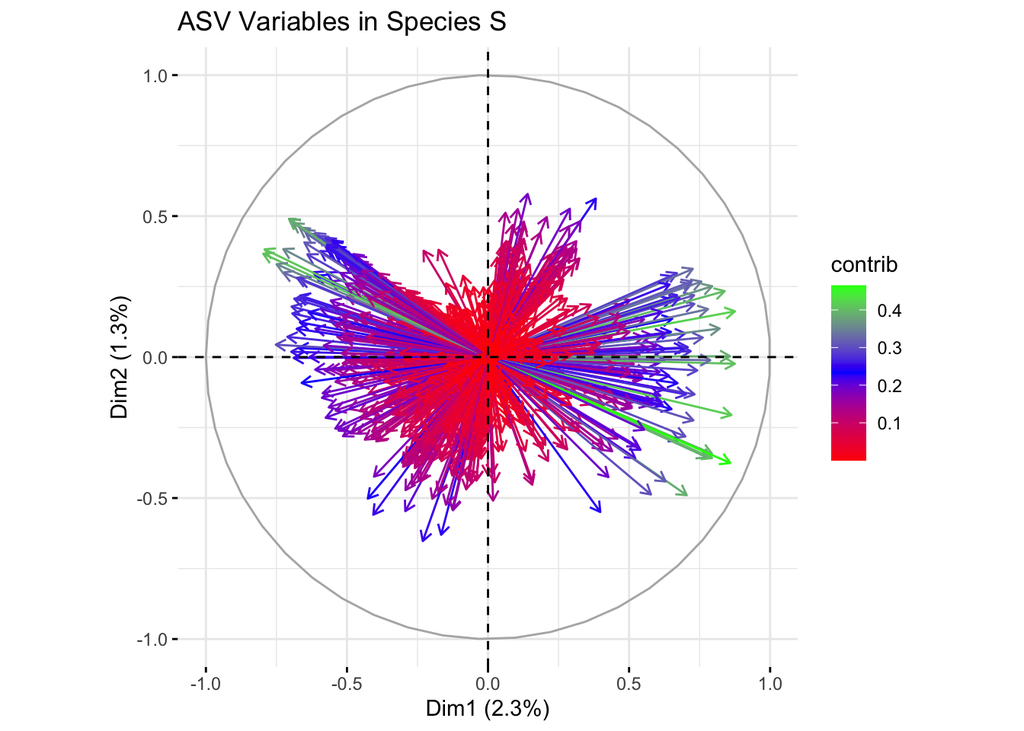

```r
fviz_pca_var(pca_out_S,
             #col.var = "steelblue",
             col.var = "contrib",
             gradient.cols = c("red", "blue", "green"),
             #repel = T,
            label = "none",
             title = "ASV Variables in Species S")
```

- This is quite different from Species P where the highest contributing only went into one quadrant. See above.

```r
get_pca_var(pca_out_S)
```

```
## Principal Component Analysis Results for variables
##  ===================================================
##   Name       Description
## 1 "$coord"   "Coordinates for the variables"
## 2 "$cor"     "Correlations between variables and dimensions"
## 3 "$cos2"    "Cos2 for the variables"
## 4 "$contrib" "contributions of the variables"
```

```r
get_pca_var(pca_out_S)$contrib %>%
  as.data.frame() %>%
  arrange(-Dim.1) -> species_S_pca_ranks
```

```r
write_csv(species_S_pca_ranks, "../output/species_S_pca_ranks.csv")
```

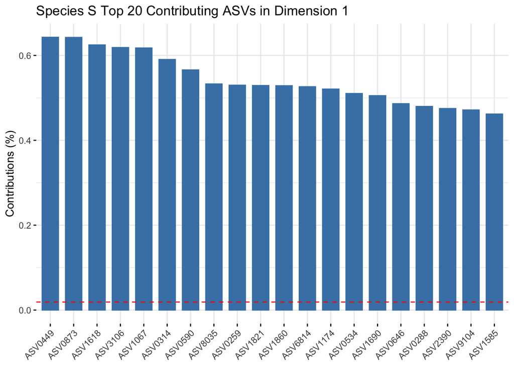

```r
fviz_contrib(pca_out_S, choice = "var", axes = 1, top = 20,
             title = "Species S Top 20 Contributing ASVs in Dimension 1",
             ggtheme = theme_minimal())  -> top_20_pca_S

top_20_pca_S
```

```r
ggsave("../plots/top_20_pca_S.png", top_20_pca_S, width = 14, bg='#ffffff')
```

# Clade C - Centered Log Ratio for Both Species

## Read in Clade C Observations

- ASV columns - all numeric

```r
read_csv("../output/clr_clade_c.csv") -> clr_clade_c
```

## Check for ‘rescale a constant/zero column to unit variance’

- If the sum of the column is 0, then the ASV column is not giving any abundance counts in this dataset for Clade C observations.

```r
map(clr_clade_c, ~mean(.)) %>%
  as.data.frame() %>%
  pivot_longer(cols = everything()) %>%
  arrange(value) %>%
  filter(value == 0) %>%
# save these into a list for removing before performing PCA
  # also need to report to client that these are NOT sequenced in these data for clade C.
  select(name) -> zero_summed_clade_c

# use the above to deselect these columns, as they will throw an error when performing PCA
clr_clade_c %>%
  select(-(zero_summed_clade_c$name)) -> clr_clade_c_non_zero
```

## PCA - Clade C

```r
stats::prcomp(clr_clade_c_non_zero,
              scale. = T) -> pca_clade_c
```

- How many ASVs in Clade C contribute 80 % of the variance?

```r
#pca_clade_c
summary(pca_clade_c)$importance %>%
  as_tibble() -> clade_c_pca_importance_matrix


bind_cols(
  name = c("StndDev", "IndivProp", "CumProp"),
  clade_c_pca_importance_matrix
) %>%
# pivoting data drame so that cumulatives are in column
  t() %>%  as.data.frame() %>%
  # moving up top row as column header
  janitor::row_to_names(1) %>% ######## snapshot here for presentation
  # filtering cumulative proportion column for greater > = 80 %
  filter(CumProp >= 0.8)
```

```
##            StndDev    IndivProp      CumProp
## PC58      4.485275     0.006240     0.802440
## PC59      4.427062     0.006080     0.808520
## PC60      4.412839     0.006040     0.814550
## PC61      4.398637     0.006000     0.820550
## PC62      4.346905     0.005860     0.826410
## PC63      4.316016     0.005770     0.832180
## PC64      4.286448     0.005700     0.837880
## PC65      4.249088     0.005600     0.843470
## PC66      4.208966     0.005490     0.848960
## PC67      4.156968     0.005360     0.854320
## PC68      4.125727     0.005280     0.859600
## PC69      4.086691     0.005180     0.864770
## PC70      4.073057     0.005140     0.869920
## PC71      4.042684     0.005070     0.874980
## PC72      4.030026     0.005030     0.880020
## PC73      3.955594     0.004850     0.884870
## PC74      3.935031     0.004800     0.889670
## PC75      3.885242     0.004680     0.894350
## PC76      3.833881     0.004560     0.898900
## PC77      3.792931     0.004460     0.903360
## PC78      3.770388     0.004410     0.907770
## PC79       3.73201      0.00432      0.91209
## PC80      3.710848     0.004270     0.916360
## PC81      3.658612     0.004150     0.920500
## PC82      3.651256     0.004130     0.924640
## PC83      3.612825     0.004050     0.928680
## PC84      3.566845     0.003940     0.932630
## PC85      3.544557     0.003890     0.936520
## PC86      3.512154     0.003820     0.940340
## PC87      3.496908     0.003790     0.944140
## PC88       3.46793      0.00373      0.94786
## PC89      3.436105     0.003660     0.951520
## PC90      3.392064     0.003570     0.955090
## PC91      3.362778     0.003510     0.958600
## PC92      3.284038     0.003340     0.961940
## PC93      3.273789     0.003320     0.965260
## PC94      3.231365     0.003240     0.968500
## PC95      3.203028     0.003180     0.971680
## PC96      3.176593     0.003130     0.974810
```

[output cut: 28 more lines]

```
## PC125 4.537588e-14 0.000000e+00 1.000000e+00
## PC126 2.558785e-14 0.000000e+00 1.000000e+00
## PC127 2.414527e-14 0.000000e+00 1.000000e+00
## PC128 1.849106e-14 0.000000e+00 1.000000e+00
## PC129 1.664664e-14 0.000000e+00 1.000000e+00
## PC130 1.437461e-14 0.000000e+00 1.000000e+00
## PC131 1.375828e-14 0.000000e+00 1.000000e+00
## PC132 1.346346e-14 0.000000e+00 1.000000e+00
## PC133 1.237087e-14 0.000000e+00 1.000000e+00
## PC134 1.189366e-14 0.000000e+00 1.000000e+00
## PC135 1.131015e-14 0.000000e+00 1.000000e+00
## PC136 1.032459e-14 0.000000e+00 1.000000e+00
## PC137 5.963607e-15 0.000000e+00 1.000000e+00
## PC138 5.424373e-15 0.000000e+00 1.000000e+00
## PC139 3.515204e-15 0.000000e+00 1.000000e+00
```

- At least 58 principal components contribute 80 % of the variance in CLade C ASV abundance data.

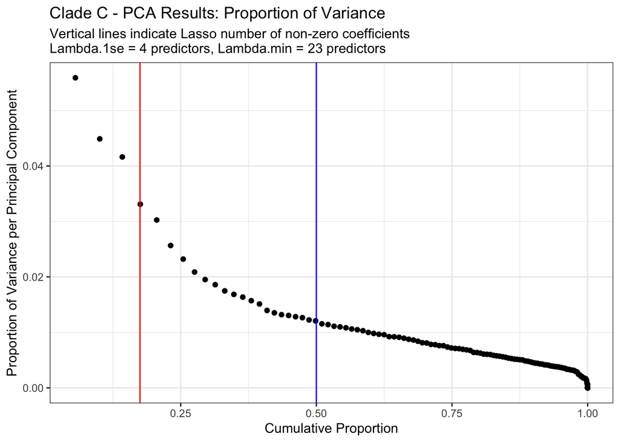

```r
bind_cols(
  name = c("StndDev", "IndivProp", "CumProp"),
  clade_c_pca_importance_matrix
) %>%
# pivoting data drame so that cumulatives are in column
  t() %>%  as.data.frame() %>%
  # moving up top row as column header
  janitor::row_to_names(1) %>%
  ggplot(aes(x = as.numeric(CumProp) , y =  as.numeric(IndivProp))) +
  geom_point() +
  ggtitle("Clade C - PCA Results: Proportion of Variance",
          "Vertical lines indicate Lasso number of non-zero coefficients\nLambda.1se = 4 predictors, Lambda.min = 23 predictors") +
  xlab("Cumulative Proportion") +
  ylab("Proportion of Variance per Principal Component") +
  theme_bw() +
  geom_vline( xintercept = 0.175, colour = "red") +
  geom_vline(xintercept = 0.5, color = "blue") #+
```

```r
  #ggrepel::geom_text_repel() +
  # annotate("text",
  #          label = "Lasso ",
  #          x = .2, y = .15,
  #          size = 8,
  #          colour = "red") +
  #  annotate("text",
  #          label = "Lasso ",
  #          x = .52, y = .15,
  #          size = 8,
  #          colour = "blue")
```

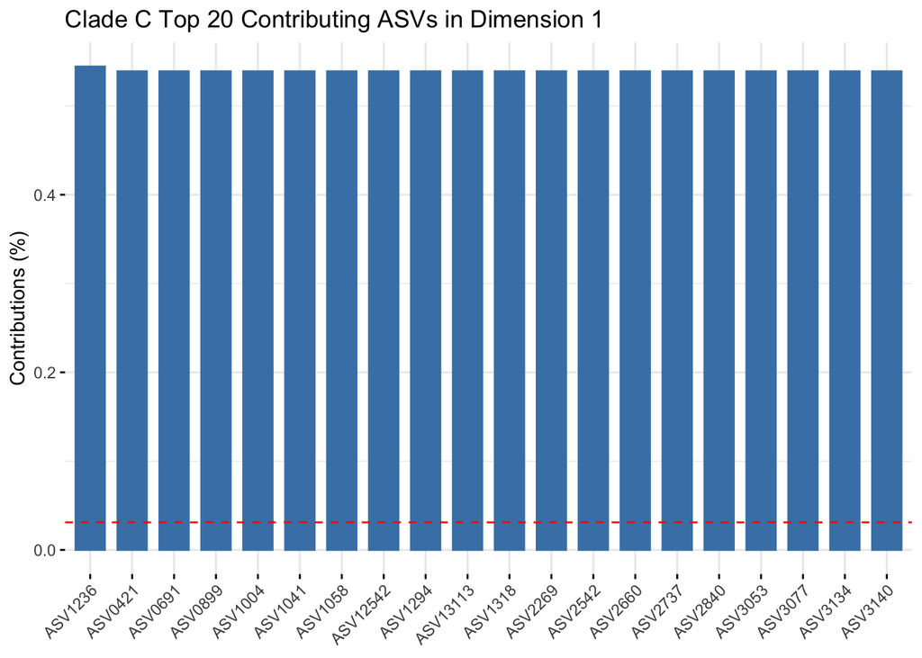

```r
library(factoextra)
fviz_contrib(pca_clade_c,
             choice = "var",
             axes = 1,
             top = 20,
             title = "Clade C Top 20 Contributing ASVs in Dimension 1",
             ggtheme = theme_minimal()) -> PCA_Clade_C_Top_20

PCA_Clade_C_Top_20
```

- From the plot above, does the bar chart ever dip? If so, how drastically? Where?

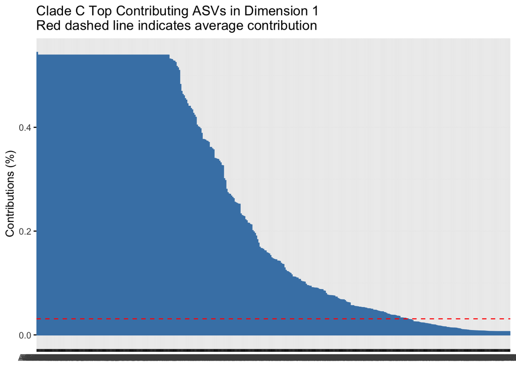

```r
fviz_contrib(pca_clade_c,
             choice = "var",
             axes = 1,
             top = 400,
             title = "Clade C Top Contributing ASVs in Dimension 1\nRed dashed line indicates average contribution",
             xtickslab.rt = 0,
             #ylim(0.4, 0.7),
             ggtheme = theme_minimal())
```

- Dashed red line indicates the average contribution of each ASV. - The plateau shape indicates that there are a subset of ASV variables in Clade C observations that contribute approximately the same amount of variability. At the point where the plateau drops, the bacteria ASVs in Clade C contribute less and less to the overall variability. - This seems to be approximately the first 100-130 ASVs for Clade C according to this particular dataset of samples.

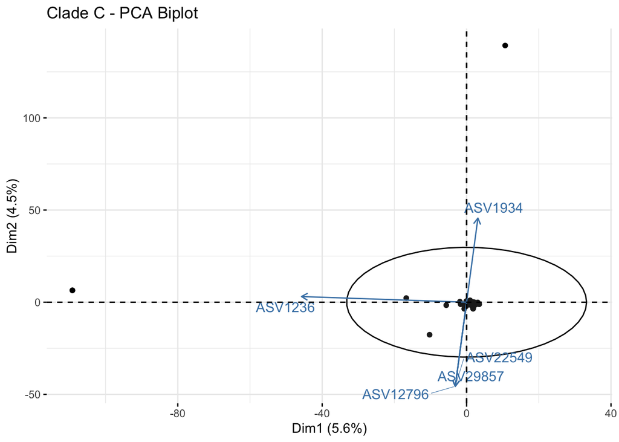

```r
fviz_pca_biplot(pca_clade_c,
                label = "var",
                addEllipses=TRUE,
                select.var = list(contrib = 5),
                repel = T,
                title = "Clade C - PCA Biplot"
                )
```

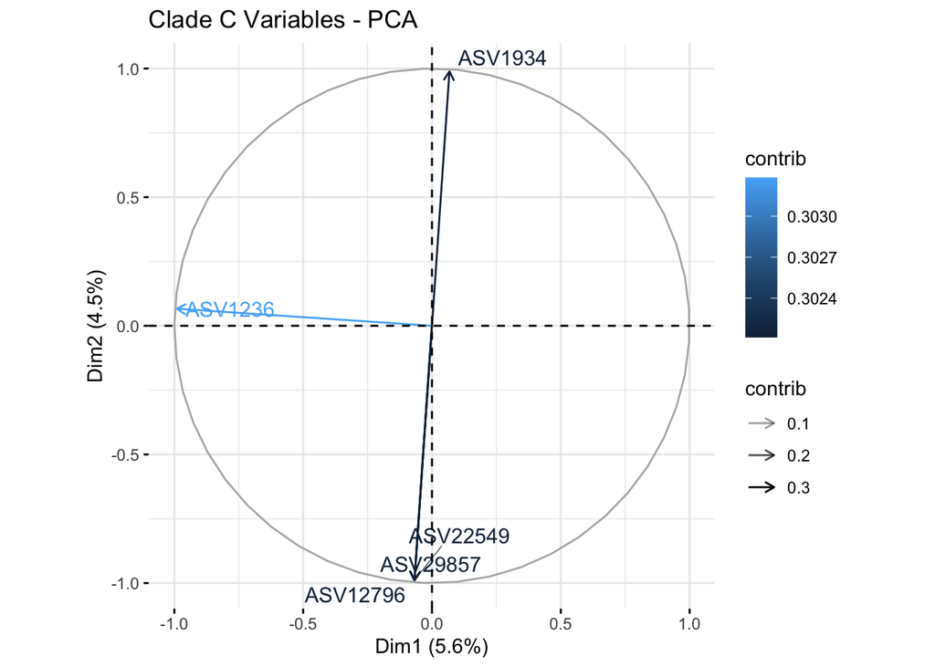

```r
fviz_pca_var(pca_clade_c,
             col.var="contrib",
             alpha.var="contrib",
             select.var = list(contrib = 5),
             repel = T,
             title = "Clade C Variables - PCA"
             )
```

- Obtain List of first 1000 ASVs for testing Logistic Regression

```r
# Access the loadings of the first two principal components
loadings <- pca_clade_c$rotation[, 1:2]

# Display the loadings to see which variables contribute the most to PC1 and PC2
#loadings

# access ordered asv names for binding columns
names(clr_clade_c_non_zero) -> asv_names
```

```r
# Take the absolute values of the loadings
abs(loadings) %>%
  as.data.frame()  -> abs_loadings


map(abs_loadings, ~abs(.)) %>%
  as.data.frame() %>%
  bind_cols("ASV" = asv_names,
            .) %>%
  arrange(-PC1) %>%
  select(ASV) -> clade_c_pca_Ranks
```

```r
write_csv(clade_c_pca_Ranks, "../output/clade_c_pca_Ranks.csv")
```